# Linkage between two markers

## Linear Regression

The linear regression model was:

rs188247550_T_C_T ~ rs58542926_T_C_T

The samples originate from the genotype dataset with identifier FTD, comprising 337.466 observations. The extracted genotype datasets were stored in *genotype_rs58542926_T_C.raw* and *genotype_rs188247550_T_C.raw*, respectively.

## Genotype vs. genotype plot

Note that rs58542926_T_C does not contain imputed values! The marker rs188247550_T_C contains 13166 imputed values.

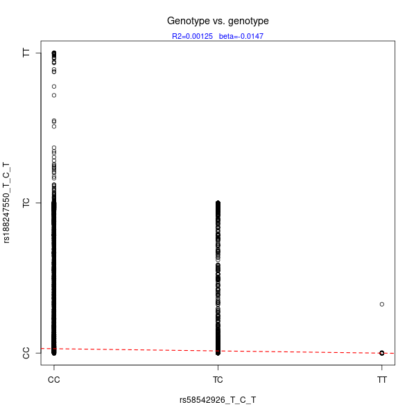

## Some metrics obtained using `lm()`:

- **sigma** is the estimatimated standard deviation of the noise term
- **Fstat** is the value of the F-statistic
- **Rsquared** is coefficient of determination
- **Rsq.adj** is coefficient of determination adjusted for the number of predictors
- **$\beta$** is the slope of the regression line
- **CI_low** is the lower limit of the confidence interval for $\beta$
- **CI_up** is the upper limit of the confidence interval for $\beta$

| sigma | Fstat | Rsquared | alpha | CI_low | beta | CI_up |
| --- | --- | --- | --- | --- | --- | --- |
| 0.156 | 423 | 0.00125 | 0.0291 | -0.0162 | -0.0147 | -0.0133 |

## Histogram for the genotype values

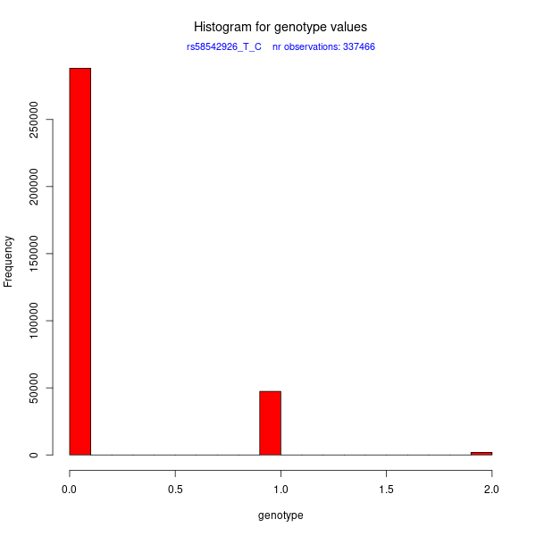

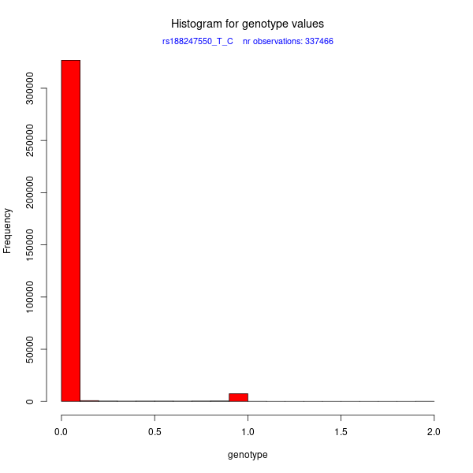

## Histogram for the imputed genotype values

Note that some markers do not comprise imputed values.

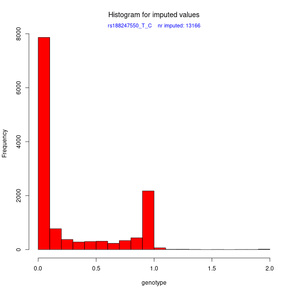

## Histogram for the magnitudes of the residuals

According to the linear model established, the residuals should be normally distributed. Consequently, the histogram below should approximately resemble a normal distribution.

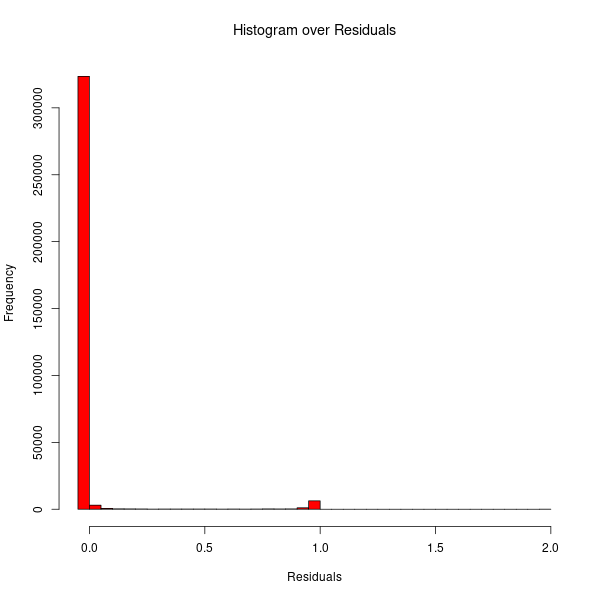

## Normal Q-Q plot of the residuals

This plot shows if residuals are normally distributed. It is desirable that the points displaying the residuals are located close to the straight line.

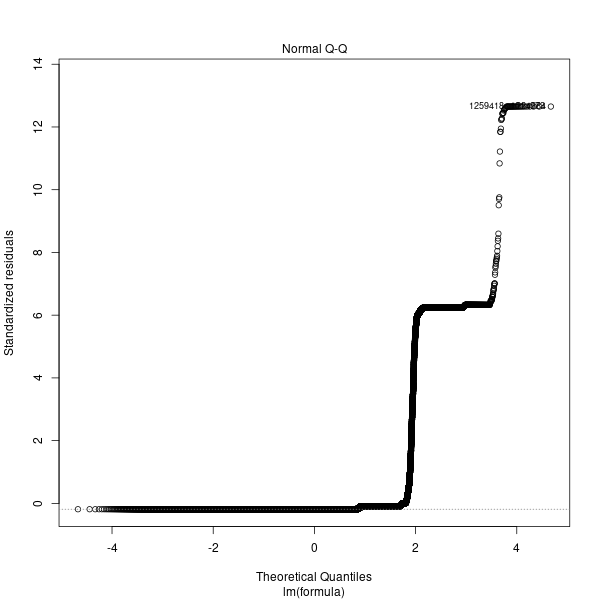

## Technical information / Help

- GWAS workfolder: /castor/project/proj/GWAS_TEST
- uwe.menzel@medsci.uu.se